# NFL 2017 Dataset Analysis

May 15, 2019

## Overview

In this project, we used a dataset of **all NFL games in the 2017 season**. We graphed and analyed the data, and here are our findings.

## About the Dataset

The dataset contains a lot of information; some important columns include the dates of games, the offense and defence teams, as well as each play of the game with details on when it occurred and what happened: quarters, times, teams, yard lines, formations, play types etc. The data is a comprehensive overview of the strategies and outcomes in the game. This dataset covers the NFL season of 2017.

## Initial Data Visualizations

We can see the frequency of each formation. The most common seem to be shotgun and undercenter

```
## [1] 1 2 4 6 7 8
```

```
## [1] SHOTGUN      UNDER CENTER UNDER CENTER UNDER CENTER UNDER CENTER
## [6] PUNT
## 8 Levels:  FIELD GOAL NO HUDDLE NO HUDDLE SHOTGUN PUNT ... WILDCAT
```

```
## formation
##        FIELD GOAL         NO HUDDLE NO HUDDLE SHOTGUN              PUNT
##              1041               642              2370              2458
##           SHOTGUN      UNDER CENTER           WILDCAT
##             18006             19996                 2
```

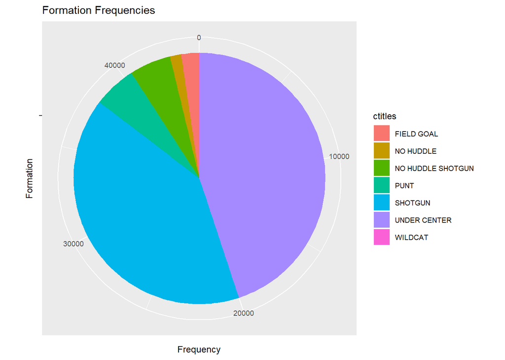

We also graphed the frequency of each play type. Pass exceeded rush, while these were the main types of plays.

```
## [1]  1  7  8  9 10 12
```

```
## [1] PASS    TIMEOUT PUNT    TIMEOUT TIMEOUT RUSH
## 17 Levels:  CLOCK STOP EXCEPTION EXTRA POINT FIELD GOAL ... TWO-POINT CONVERSION
```

```
## playtype
##           CLOCK STOP            EXCEPTION          EXTRA POINT
##                   55                   98                 1138
##           FIELD GOAL              FUMBLES             KICK OFF
##                 1042                  102                 2562
##              NO PLAY                 PASS              PENALTY
##                  785                18448                    2
##                 PUNT             QB KNEEL                 RUSH
##                 2544                  396                12673
##                 SACK             SCRAMBLE              TIMEOUT
##                 1265                  762                 1785
## TWO-POINT CONVERSION
##                   89
```

```
## EXTRA POINT  FIELD GOAL    KICK OFF        PASS        PUNT        RUSH
##        1138        1042        2562       18448        2544       12673
##        SACK     TIMEOUT       OTHER
##        1265        1785        2289
```

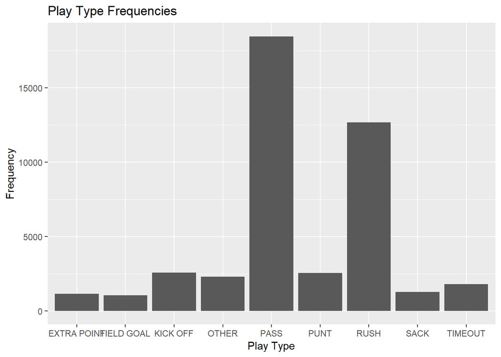

Another interesting visualization was the number of yards gained on rush plays. There is a peak at zero yards, though in this case the count for small numbers of yards above 0 is also fairly high. This speaks to the frequency of rush plays in the NFL which result in small but safe yard gains leading up to first downs, or to rushes employed inches or a few yards from the end zone. The histogram is skewed to the right, as expected.

```
## [1] 12 22 26 29 36 38
```

```
## [1] 0 6 1 3 3 0
```

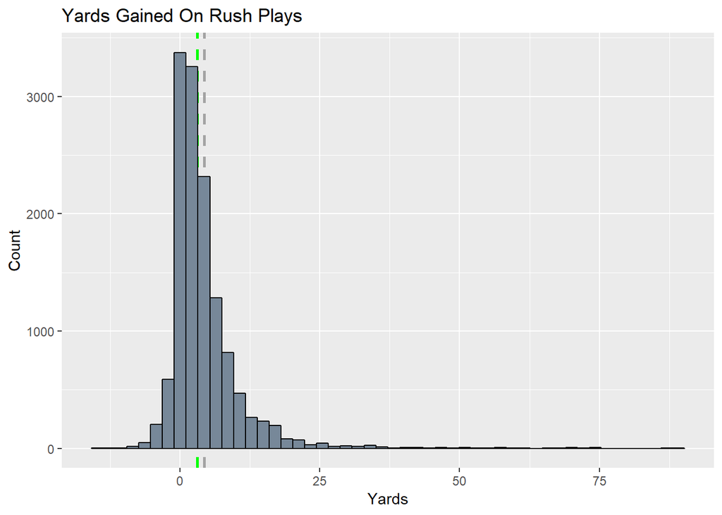

## Permutation Test

We computed a permutation test to see if the number of touchdowns per game scored in the first half of the season differs from the number of touchdowns scored in the second half of the season

```r
istouchdown <- which(dataset$IsTouchdown == 1)

# If we do this, use the following data:
ElapsedDays <- as.numeric(difftime(as.Date(dataset$GameDate, "%m/%d/%y"), as.Date(dataset$GameDate[1], "%m/%d/%y"), units = "days")); head(ElapsedDays)
```

```
## [1] 0 3 3 3 3 3
```

```r
# This gives is the number of days since the start of the season. 9/7/17 returns 0 and
# 12/31/17 returns 115. Since the season has 116 days, the first half of the season is days (0, 57)
# and the second half is days (58, 115)

# First get the touchdowns per game in the first half of the season
S1index <- which(ElapsedDays < 58 );
half1 <- intersect(istouchdown,S1index);
tbl1 <- table(dataset$GameId[half1]);
mean(tbl1)
```

```
## [1] 5.322034
```

```r
# Get the number of touchdowns in the second half of the season
S2index <- which(ElapsedDays > 57 );
half2 <- intersect(istouchdown,S2index);
tbl2 <- table(dataset$GameId[half2]);
mean(tbl2)
```

```
## [1] 5.2
```

```r
# Find the difference in means
difference <- mean(tbl1)-mean(tbl2); difference
```

```
## [1] 0.1220339
```

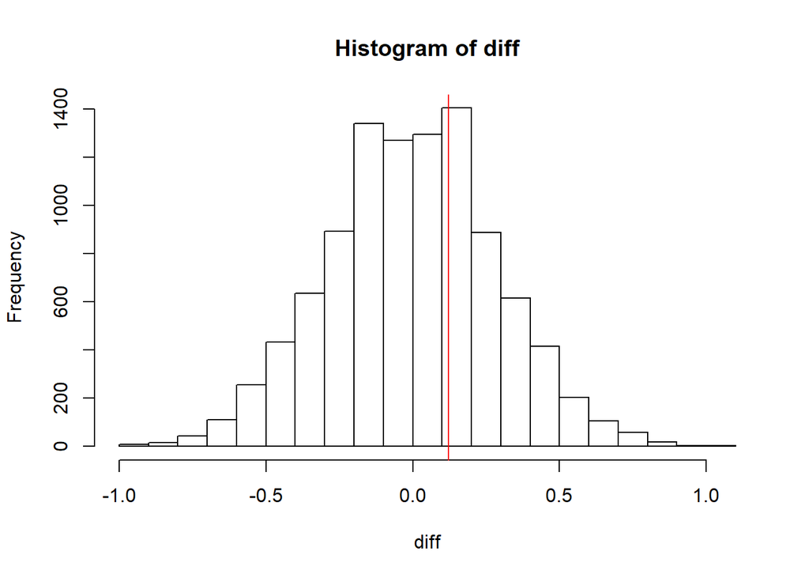

```r
# Get just the wins column
vec1 <- as.numeric(as.matrix(tbl1));
vec2 <- as.numeric(as.matrix(tbl2));
touchdowns <- c(vec1,vec2);

# Run a permutation test by scrambling the touchdowns vector
N <-10000; diff <- numeric(N)
for (i in 1:N) {
  scramble <- sample(touchdowns,length(touchdowns))
  diff[i] <- mean(scramble[0:127])-mean(scramble[128:253])
}
hist(diff)
abline(v=difference, col = "red")
```

```r
pvalue <- mean(diff > difference); pvalue
```

```
## [1] 0.3302
```

The pvalue is large, so there seems to be no significant correlation

## Linear Regression

We find that the there is a relatively constant relationship between starting yard line and average number of yards gained or lost, but the data have a very interesting shape. Here is what the distribution looks like, in a ggplot:

```
## [1] 99  0  0  0  0  0
```

```
## [1] -2  0  0  0  0  0
```

```
## [1]  1 21 24 40 42 43
```

```
## [1] 99 40 55 50 40  9
```

```
## [1] -2  8  0 -1  0  8
```

```
##
## Call:
## lm(formula = yardsRushPass ~ yardlineRushPass)
##
## Residuals:
##     Min      1Q  Median      3Q     Max
## -20.576  -5.508  -2.579   2.453  98.631
##
## Coefficients:
##                   Estimate Std. Error t value Pr(>|t|)
## (Intercept)       7.714390   0.110009   70.12   <2e-16 ***
## yardlineRushPass -0.035587   0.002061  -17.27   <2e-16 ***
## ---
## Signif. codes:  0 '***' 0.001 '**' 0.01 '*' 0.05 '.' 0.1 ' ' 1
##
## Residual standard error: 8.915 on 31881 degrees of freedom
## Multiple R-squared:  0.009268,   Adjusted R-squared:  0.009237
## F-statistic: 298.3 on 1 and 31881 DF,  p-value: < 2.2e-16
```

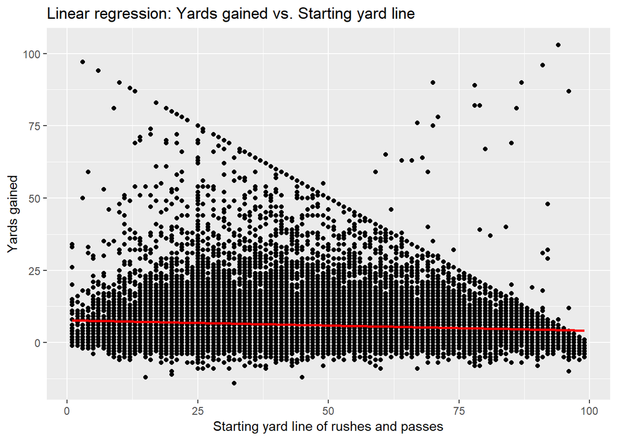

## Probability density overlaid on a histogram

We used a probability density plot to analyze timeouts as they are taken at different points in the half. Below, we have the frequency of timeout 1 usage with elapsed seconds. One can see that timeout 1 is used at all sorts of points, but it is most common to use it later in the half (in direr situations!).

```
## [1] 1837 1740 1860 3540  960 3540
```

```
## [1]  5  8 12 17 29 34
```

```
## [1]  9 13 15 25 31 37
```

```
## [1]  37  89 161 222 244 247
```

```
## [1] 1353.367
```

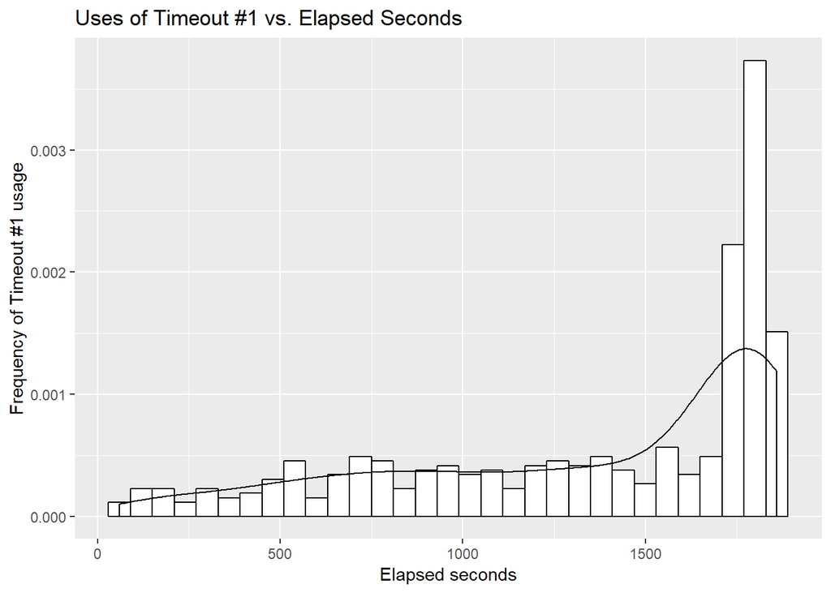

## Logistic Regression

We used logistic regression to analyze the decision to rush or pass the ball. We find that yard line and proportion of plays that are rushes vs. passes is fairly constant (about 40% of the plays result in rushes). We perform numerous (~30) such additional logistic regressions, many with interesting results, in the longer script!

```
## [1] 99  0  0  0  0  0
```

```
## [1]  923 1020  900 2820    0 2820
```

```
## [1] 0 3 3 3 3 3
```

```
## [1]  1 21 24 40 42 43
```

```
## [1] 99 40 55 50 40  9
```

```
## [1]  923  936 1566 2929 3391 3347
```

```
## [1] 0 3 3 4 7 7
```

```
## [1] 0 0 0 0 0 0
```

```
## [1] 1 1 1 1 1 1
```

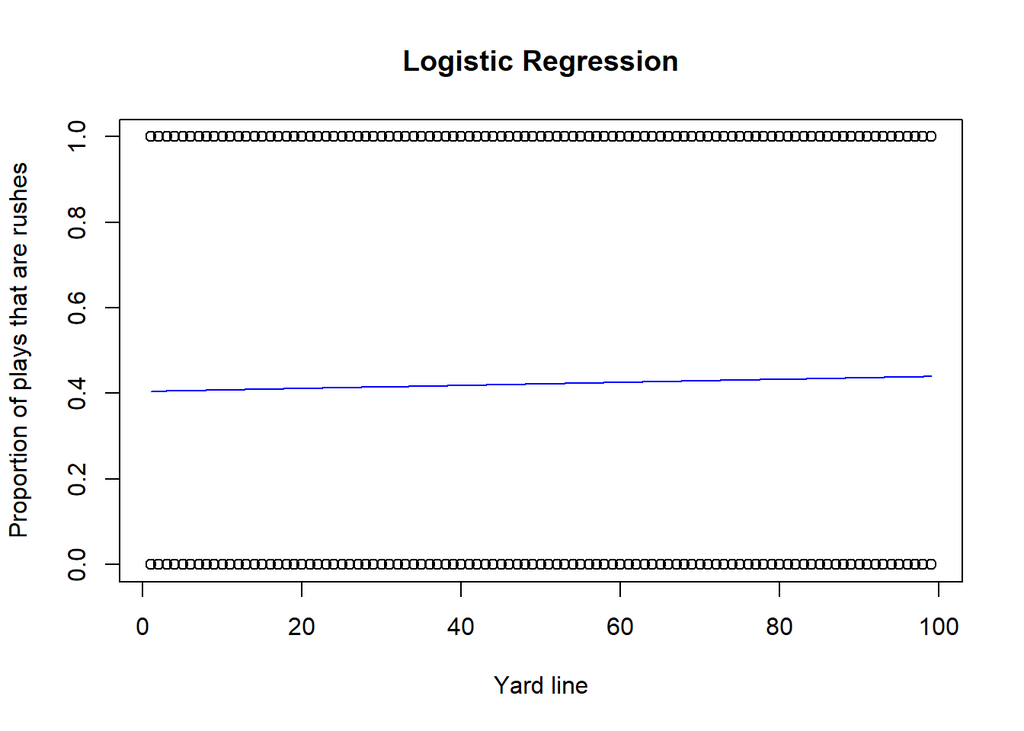